# Setup / EDA

- 분석에 앞서 환경설정을 하고 데이터를 살펴보자.

```r
library(tidyr)
library(dplyr)
library(broom)
library(ggplot2)
library(OpenMx)
data(twinData)
twinData <- as_tibble(twinData)
head(twinData)
```

```
## # A tibble: 6 x 16
##     fam   age   zyg  part   wt1   wt2   ht1   ht2 htwt1 htwt2  bmi1  bmi2
##   <int> <int> <int> <int> <int> <int> <dbl> <dbl> <dbl> <dbl> <dbl> <dbl>
## 1     1    21     1     2    58    57  1.7   1.7   20.1  19.7  21.0  20.9
## 2     2    24     1     2    54    53  1.63  1.63  20.3  19.9  21.1  21.0
## 3     3    21     1     2    55    50  1.65  1.68  20.2  17.7  21.0  20.1
## 4     4    21     1     2    66    76  1.57  1.65  26.8  27.9  23.0  23.3
## 5     5    19     1     2    50    48  1.61  1.63  19.3  18.1  20.7  20.3
## 6     6    26     1     2    60    60  1.60  1.57  23.4  24.3  22.1  22.3
## # ... with 4 more variables: cohort <chr>, zygosity <fct>, age1 <int>,
## #   age2 <int>
```

twinData는 쌍둥이의 Cohort연구로써 ht1, wt1는 각각 일찍태어난 쌍둥이의 키, 무게 ht2, wt2는 각각 늦게 태어난 쌍둥이의 값들이다.

- 데이터구조 살펴보기

```r
str(twinData)
```

```
## Classes 'tbl_df', 'tbl' and 'data.frame':    3808 obs. of  16 variables:
##  $ fam     : int  1 2 3 4 5 6 7 8 9 10 ...
##  $ age     : int  21 24 21 21 19 26 23 29 24 28 ...
##  $ zyg     : int  1 1 1 1 1 1 1 1 1 1 ...
##  $ part    : int  2 2 2 2 2 2 2 2 2 2 ...
##  $ wt1     : int  58 54 55 66 50 60 65 40 60 76 ...
##  $ wt2     : int  57 53 50 76 48 60 65 39 57 64 ...
##  $ ht1     : num  1.7 1.63 1.65 1.57 1.61 ...
##  $ ht2     : num  1.7 1.63 1.68 1.65 1.63 ...
##  $ htwt1   : num  20.1 20.3 20.2 26.8 19.3 ...
##  $ htwt2   : num  19.7 19.9 17.7 27.9 18.1 ...
##  $ bmi1    : num  21 21.1 21 23 20.7 ...
##  $ bmi2    : num  20.9 21 20.1 23.3 20.3 ...
##  $ cohort  : chr  "younger" "younger" "younger" "younger" ...
##  $ zygosity: Factor w/ 5 levels "MZFF","MZMM",..: 1 1 1 1 1 1 1 1 1 1 ...
##  $ age1    : int  21 24 21 21 19 26 23 29 24 28 ...
##  $ age2    : int  21 24 21 21 19 26 23 29 24 28 ...
```

위는 데이터 구조를 전개한 모습이다.

corhort: 연구집단으로 Younger 어린집단, Older: 노인집단  
Zygosity: MZ는 일란성, DZ는 이란성 M, F은 각각 성별이며 DZOZ는 이란성쌍둥이 중 성별이 다른쌍둥이이다.  
더욱 자세한 변수설명은 help(twinData) 명령어를 통해 확인 할 수 있다.

- zygosity 기준별 산점

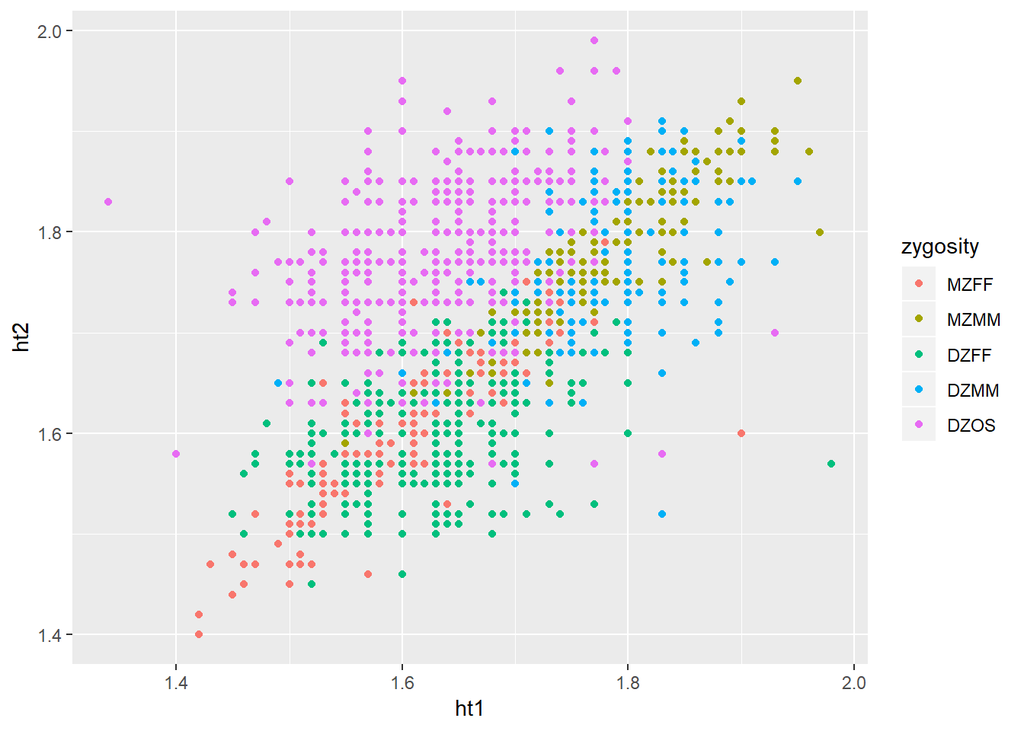

```r
twinData %>% ggplot(mapping = aes(ht1, ht2,colour = zygosity)) +
  geom_point()
```

위의 그림은 모든데이터에 Zygosity를 Label로 정하여 ht1과 ht2의 산점도 그림이다.

# Excercise 8

17. cohort, zygosity 기준으로 각 하위그룹에 대하여 도시하고, 키 변수간 유의미한 유사성을 색깔로 표현하고 코멘트를 추가하라.

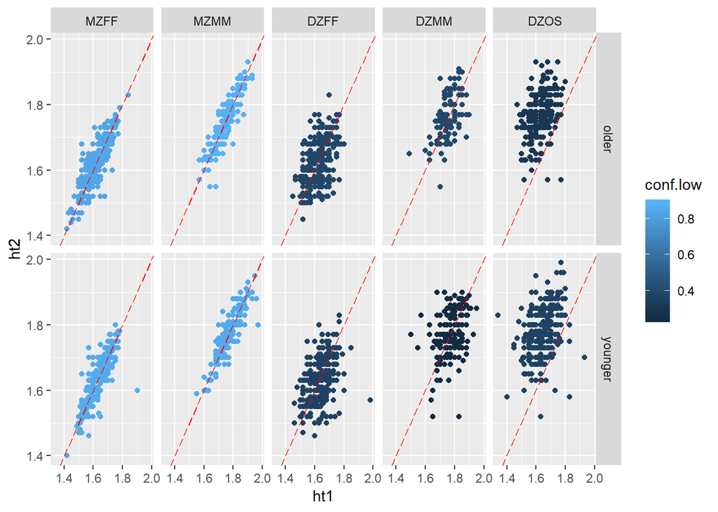

```r
a<- twinData %>% group_by(cohort,zygosity) %>%
  do(tidy(cor.test(~ht1+ht2, alternative = 'greater', data =.))) %>%
  select(cohort,zygosity, conf.low)

twinData %>%
  inner_join(a) %>%
  group_by(cohort,zygosity) %>% ggplot(mapping = aes(ht1, ht2, colour = conf.low)) +
  geom_point() + facet_grid(rows =vars(cohort), cols =vars(zygosity)) +
  geom_abline(a=1, b=0, color ='red', linetype = 'longdash')
```

# Excercise 9

- cohort, zygosity 기준으로 각 하위그룹에 대하여 도시하고, 몸무게 변수간 유의미한 유사성을 색깔로 표현하고 코멘트를 추가하라.

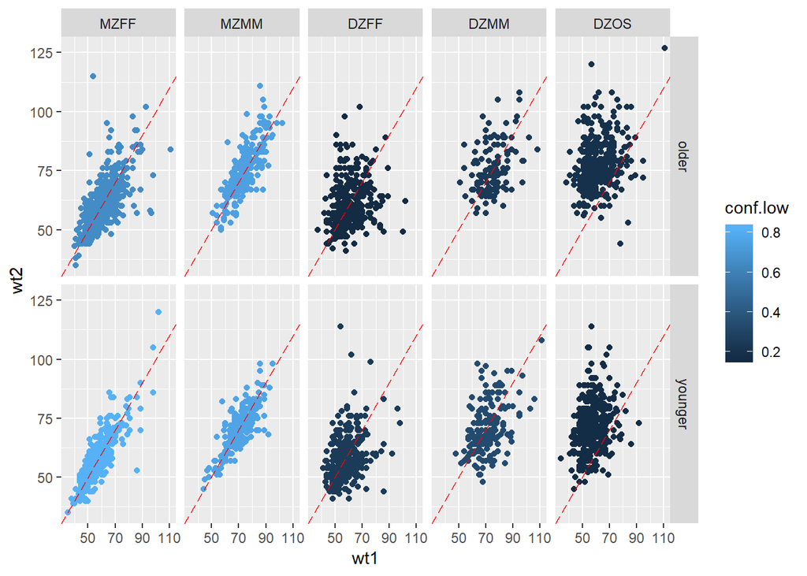

```r
b<- twinData %>% group_by(cohort,zygosity) %>%
  do(tidy(cor.test(~wt1+wt2, alternative = 'greater', data =.))) %>%
  select(cohort,zygosity, conf.low)

twinData %>%
  inner_join(b) %>%
  group_by(cohort,zygosity) %>% ggplot(mapping = aes(wt1, wt2, colour = conf.low)) +
  geom_point() + facet_grid(rows =vars(cohort), cols =vars(zygosity)) +
  geom_abline(a=1, b=0, color ='red',linetype="longdash")
```

문제 8번과 동일하게 wt1/wt2에 대해서 산점도를 그려보았다. 키와 동일하게 몸무게에 대해서도 두 쌍둥이에 대한 상관관계의 경향성이 같아 보인다.

# Excercise 10

- gather()함수를 사용하여 twinData를 하위그룹으로 도식화하라

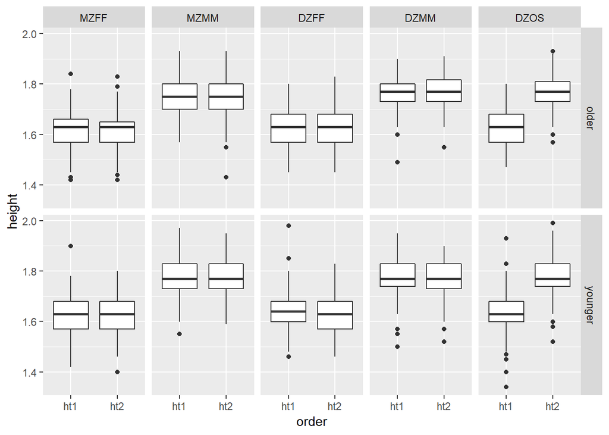

```r
gathered_twinData <- twinData %>% gather(order, height, ht1, ht2)
gathered_twinData %>% ggplot(mapping = aes(order, height)) +
  geom_boxplot() +  facet_grid(cohort ~ zygosity)
```

위 그림은 Gather함수를 사용하여 Cohort와 Zigosity의 하위그룹으로 나눈 것이다.

# Excercise 11

17. 위 의 boxplot을 볼때 처음 가설을 조정해야할 필요가 있는지 논의하시요.
18. 전체 산점도를 보았을 때는 ht1, ht2 변수간 상관관계가 높은 것으로 판단되었으나 각 하위그룹별로 보았을때 이란성 다른성별(DZOS)의 하위그룹의 집단의 키가 달라보인다. 정확한 추론을 위하여 하기에 각각 유의성 검정을 해볼 필요성이 대두되었다.
- MZFF 그룹

```r
twin_MZFF <- twinData %>% filter(zygosity =='MZFF')
t.test(twin_MZFF$ht1, twin_MZFF$ht2, alternative = 'two.sided', paired=T)
```

```
##
##  Paired t-test
##
## data:  twin_MZFF$ht1 and twin_MZFF$ht2
## t = 0.79488, df = 1192, p-value = 0.4268
## alternative hypothesis: true difference in means is not equal to 0
## 95 percent confidence interval:
##  -0.001129422  0.002667896
## sample estimates:
## mean of the differences
##            0.0007692372
```

쌍체검정을 해본 결과 p= 0.42로 두 집단은 귀무가설인 ht1=th2를 채택하게된다.

- DZOS 그룹

```r
twin_DZOS <- twinData %>% filter(zygosity =='DZOS')
t.test(twin_DZOS$ht1, twin_DZOS$ht2, alternative = 'two.sided', paired=T, data = twin_DZOS)
```

```
##
##  Paired t-test
##
## data:  twin_DZOS$ht1 and twin_DZOS$ht2
## t = -59.091, df = 865, p-value < 2.2e-16
## alternative hypothesis: true difference in means is not equal to 0
## 95 percent confidence interval:
##  -0.1468676 -0.1374248
## sample estimates:
## mean of the differences
##              -0.1421462
```

# Exercise 12

Q1) 왜 쌍체검정을 사용해야하는가?  
A1) 쌍둥이 집단은 서로 독립이 아니다. 쌍둥이라는 특징을 가진 종속변수이기 때문에 의약품 투여, 쌍둥이 연구는 쌍체검정을 시행해야 한다.

Q2) 각 그룹에 대하여 5% 유의검정을 시행하라.

```r
twinData_p <-twinData %>% group_by(zygosity, cohort) %>%
  do(tidy(t.test(.$ht1, .$ht2, alternative = 'two.sided', paired=T,data = .)))
twinData_p
```

```
## # A tibble: 10 x 10
## # Groups:   zygosity, cohort [10]
##    zygosity cohort   estimate statistic   p.value parameter   conf.low
##    <fct>    <chr>       <dbl>     <dbl>     <dbl>     <dbl>      <dbl>
##  1 MZFF     older    0.00127      0.953 3.41e-  1       643 -0.00135
##  2 MZFF     younger  0.000180     0.128 8.98e-  1       548 -0.00258
##  3 MZMM     older   -0.000239    -0.131 8.95e-  1       287 -0.00382
##  4 MZMM     younger  0.00128      0.635 5.26e-  1       257 -0.00270
##  5 DZFF     older    0.00314      0.916 3.60e-  1       388 -0.00360
##  6 DZFF     younger  0.00761      1.94  5.30e-  2       340 -0.0000986
##  7 DZMM     older   -0.00635     -1.20  2.31e-  1       139 -0.0168
##  8 DZMM     younger  0.00213      0.376 7.07e-  1       191 -0.00903
##  9 DZOS     older   -0.141      -40.5   9.99e-140       379 -0.148
## 10 DZOS     younger -0.143      -43.2   3.16e-168       485 -0.149
## # ... with 3 more variables: conf.high <dbl>, method <chr>,
## #   alternative <chr>
```

실행 결과 DZOS의 2개 cohort그룹에 대해서만 유의한 결과가 나왔다.

Q3) t-test시행 결과를 색깔로 보여주는 그래프를 그려라.

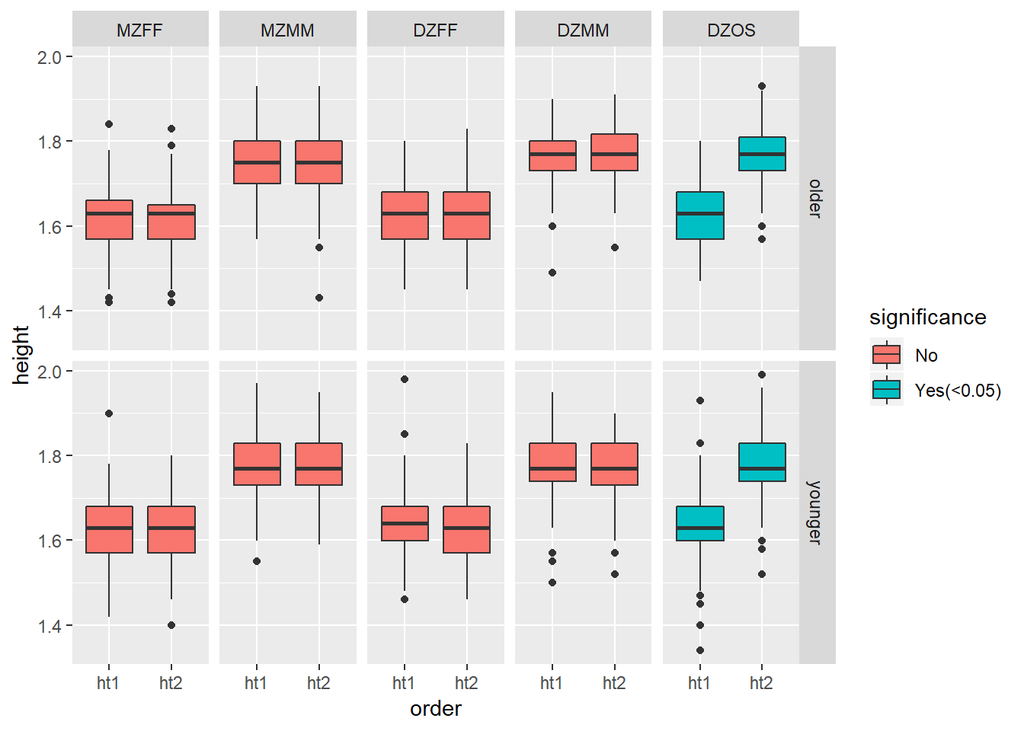

```r
gathered_twinData <- twinData %>% gather(order, height, ht1, ht2)
gathered_twinData %>% inner_join(twinData_p, by = c('cohort', 'zygosity')) %>%
  mutate(significance = ifelse(p.value<0.05, 'Yes(<0.05)', 'No')) %>%
  ggplot(mapping = aes(order, height, fill = significance)) +
  geom_boxplot() + facet_grid(cohort ~ zygosity)
```

위 그래프가 보여주는 내용은 DZOS의 younger, older그룹에서 ht1, ht2변수가 유의하게 다름을 5% 유의수준에서 확인 한것을 도식화 한 것이다.